# Final Project: 2018 Match Analysis - First Robotics Compition

## Where is your data from?

#### [Dataset From Kaggle https://www.kaggle.com/samcfuchs/frc-2018](https://www.kaggle.com/samcfuchs/frc-2018)

## Game Preview

[figure not shown]

## Event Details

[2018 FRCGame Season Manual](https://firstfrc.blob.core.windows.net/frc2018/Manual/2018FRCGameSeasonManual.pdf)

[PNW District Auburn Event 2018](https://www.thebluealliance.com/event/2018waahs)

[PNW District Auburn Event Insights 2018](https://www.thebluealliance.com/event/2018waahs#event-insights)

[PNW District Auburn Mountainview Event 2018](https://www.thebluealliance.com/event/2018waamv)

[PNW District Auburn Mountainview Event Insights 2018](https://www.thebluealliance.com/event/2018waamv#event-insights)

[Team 2927: πRho Techs](https://www.thebluealliance.com/team/2927/2018)

## What were you looking to answer and predictions you wanted to make?

1. Points Analysis
   - How were points distributed?
2. Obsticle Analysis
   - What obsticles where used most often?
   - What obsticle(s) affected win/lose ratio the most?
3. Other Analysis

## A brief summary of your methodology for answering these questions

Using Clustering, Classification, and Regression analysis methods we plan to simplify and deduce the order and magnitude in which something affects the outcome of another.

√ 1- Apply supervised or un-supervised models to a dataset (or problem) you are interested in. Investigate variety of steps to make the model better including:

- Hyper-parameter tuning by Grid-search
- Check if dataset is balanced or not -> change the threshold
- √ Data preprocessing (scaling)
- √ Dimensionality reduction (PCA) -> train the model based on X_reduced_train and Y_reduced_train
- √ Eliminate unnecessary features -> Feature Engineering
- √ Try other models and do the above all steps

√ 2- Read blogs about Feature Engineering and make your model performance better with variety of Feature Engineering options:

- √ Using Fitted and Embedded Methods to do analysis
- √ https://towardsdatascience.com/feature-selection-correlation-and-p-value-da8921bfb3cf
- √ https://towardsdatascience.com/feature-selection-with-pandas-e3690ad8504b

3- Build a Decision Tree (DT) classifier from Scratch (you can use Pandas or any other Python built-in functions) and provide DT visualization. For any categorical dataset, your function should return the optimal tree with the root and all appropriate leafs, max_depth of the tree and the visualized graph. You can follow the steps we explored in class but should work for any dataset for example if we pass Lens dataset.

# DataFarme Setup/Cleaning

```python
pd.set_option('display.max_columns', None)
data = pd.read_csv('2018_MatchData.csv').set_index("Week")
data = Team2927 = data[data['Team'] == 2927].set_index(['Event', 'Match', 'Alliance'])
data = data.drop(['City','State','Country','Time','autoQuestRankingPoint','autoRun','autoSwitchAtZero','endgame','faceTheBossRankingPoint','Robot Number', 'adjustPoints', 'tba_gameData'], axis=1)

label_encoder = LabelEncoder()
for i in data.columns:
    data[i] = label_encoder.fit_transform(data[i]).astype('float64')

# result = label_encoder.fit_transform(data['result']).astype('float64')
result = data.result
data = data.drop(columns=['Team'])

x_train, x_test, y_train, y_test = train_test_split(data.values, result.values, test_size = 0.3)
```

```python
data
# result
```

| Event | Match | Alliance | autoOwnershipPoints | autoPoints | autoRunPoints | autoScaleOwnershipSec | autoSwitchOwnershipSec | endgamePoints | foulCount | foulPoints | rp | techFoulCount | teleopOwnershipPoints | teleopPoints | teleopScaleBoostSec | teleopScaleForceSec | teleopScaleOwnershipSec | teleopSwitchBoostSec | teleopSwitchForceSec | teleopSwitchOwnershipSec | totalPoints | vaultBoostPlayed | vaultBoostTotal | vaultForcePlayed | vaultForceTotal | vaultLevitatePlayed | vaultLevitateTotal | vaultPoints | result | … |
| --- | --- | --- | --- | --- | --- | --- | --- | --- | --- | --- | --- | --- | --- | --- | --- | --- | --- | --- | --- | --- | --- | --- | --- | --- | --- | --- | --- | --- | --- | --- |
| waahs | qf4m1 | red | 0.0 | 2.0 | 2.0 | 0.0 | 0.0 | 5.0 | 6.0 | 2.0 | 0.0 | 0.0 | 24.0 | 25.0 | 0.0 | 0.0 | 18.0 | 2.0 | 0.0 | 13.0 | 26.0 | 1.0 | 1.0 | 0.0 | 0.0 | 1.0 | 2.0 | 4.0 | 1.0 | … |
|  | qf4m2 | red | 2.0 | 5.0 | 2.0 | 1.0 | 1.0 | 3.0 | 1.0 | 2.0 | 0.0 | 0.0 | 16.0 | 16.0 | 3.0 | 2.0 | 7.0 | 0.0 | 0.0 | 18.0 | 14.0 | 2.0 | 2.0 | 2.0 | 2.0 | 0.0 | 0.0 | 4.0 | 1.0 | … |
|  | qm1 | red | 0.0 | 1.0 | 1.0 | 0.0 | 0.0 | 0.0 | 4.0 | 2.0 | 0.0 | 0.0 | 4.0 | 1.0 | 0.0 | 0.0 | 11.0 | 0.0 | 0.0 | 0.0 | 1.0 | 0.0 | 0.0 | 0.0 | 0.0 | 0.0 | 1.0 | 2.0 | 0.0 | … |
|  | qm15 | blue | 6.0 | 8.0 | 1.0 | 0.0 | 5.0 | 4.0 | 1.0 | 1.0 | 2.0 | 0.0 | 21.0 | 21.0 | 2.0 | 0.0 | 12.0 | 2.0 | 0.0 | 18.0 | 23.0 | 3.0 | 3.0 | 0.0 | 0.0 | 1.0 | 2.0 | 6.0 | 1.0 | … |
|  | qm19 | red | 0.0 | 1.0 | 1.0 | 0.0 | 0.0 | 4.0 | 2.0 | 3.0 | 0.0 | 0.0 | 7.0 | 7.0 | 0.0 | 0.0 | 0.0 | 0.0 | 0.0 | 11.0 | 8.0 | 0.0 | 0.0 | 0.0 | 0.0 | 1.0 | 2.0 | 3.0 | 0.0 | … |
|  | qm27 | red | 3.0 | 4.0 | 1.0 | 0.0 | 2.0 | 3.0 | 1.0 | 8.0 | 2.0 | 0.0 | 9.0 | 12.0 | 0.0 | 0.0 | 2.0 | 0.0 | 0.0 | 18.0 | 18.0 | 0.0 | 0.0 | 0.0 | 0.0 | 1.0 | 2.0 | 3.0 | 1.0 | … |
|  | qm35 | blue | 0.0 | 2.0 | 2.0 | 0.0 | 0.0 | 4.0 | 0.0 | 7.0 | 2.0 | 0.0 | 10.0 | 14.0 | 0.0 | 2.0 | 9.0 | 2.0 | 0.0 | 6.0 | 16.0 | 3.0 | 3.0 | 2.0 | 3.0 | 1.0 | 2.0 | 8.0 | 1.0 | … |
|  | qm39 | blue | 5.0 | 7.0 | 1.0 | 0.0 | 4.0 | 5.0 | 0.0 | 2.0 | 2.0 | 0.0 | 19.0 | 23.0 | 3.0 | 0.0 | 15.0 | 0.0 | 0.0 | 11.0 | 24.0 | 2.0 | 2.0 | 0.0 | 0.0 | 1.0 | 2.0 | 5.0 | 1.0 | … |
|  | qm45 | blue | 0.0 | 1.0 | 1.0 | 0.0 | 0.0 | 3.0 | 0.0 | 1.0 | 0.0 | 0.0 | 8.0 | 11.0 | 0.0 | 1.0 | 1.0 | 0.0 | 0.0 | 16.0 | 10.0 | 0.0 | 0.0 | 2.0 | 2.0 | 1.0 | 2.0 | 5.0 | 0.0 | … |
|  | qm53 | blue | 5.0 | 10.0 | 2.0 | 0.0 | 4.0 | 5.0 | 1.0 | 1.0 | 3.0 | 0.0 | 20.0 | 24.0 | 1.0 | 0.0 | 13.0 | 0.0 | 0.0 | 18.0 | 25.0 | 2.0 | 2.0 | 0.0 | 1.0 | 1.0 | 2.0 | 6.0 | 1.0 | … |
|  | qm55 | red | 0.0 | 2.0 | 2.0 | 0.0 | 0.0 | 5.0 | 0.0 | 5.0 | 0.0 | 1.0 | 6.0 | 10.0 | 0.0 | 0.0 | 0.0 | 0.0 | 0.0 | 10.0 | 11.0 | 0.0 | 0.0 | 0.0 | 0.0 | 1.0 | 2.0 | 3.0 | 0.0 | … |
|  | qm64 | blue | 5.0 | 10.0 | 2.0 | 0.0 | 4.0 | 5.0 | 0.0 | 0.0 | 1.0 | 0.0 | 0.0 | 5.0 | 0.0 | 2.0 | 4.0 | 0.0 | 0.0 | 1.0 | 5.0 | 0.0 | 0.0 | 2.0 | 2.0 | 1.0 | 2.0 | 5.0 | 0.0 | … |
|  | qm68 | red | 0.0 | 2.0 | 2.0 | 0.0 | 0.0 | 4.0 | 5.0 | 0.0 | 0.0 | 0.0 | 2.0 | 4.0 | 0.0 | 0.0 | 0.0 | 0.0 | 0.0 | 3.0 | 3.0 | 0.0 | 0.0 | 0.0 | 0.0 | 1.0 | 2.0 | 3.0 | 0.0 | … |
|  | qm9 | red | 0.0 | 0.0 | 0.0 | 0.0 | 0.0 | 4.0 | 3.0 | 1.0 | 0.0 | 0.0 | 6.0 | 8.0 | 0.0 | 0.0 | 0.0 | 2.0 | 1.0 | 8.0 | 6.0 | 1.0 | 1.0 | 1.0 | 1.0 | 1.0 | 2.0 | 5.0 | 0.0 | … |
|  | sf2m1 | blue | 1.0 | 3.0 | 2.0 | 0.0 | 1.0 | 3.0 | 1.0 | 0.0 | 0.0 | 1.0 | 4.0 | 2.0 | 0.0 | 0.0 | 0.0 | 0.0 | 0.0 | 5.0 | 2.0 | 0.0 | 0.0 | 0.0 | 0.0 | 0.0 | 0.0 | 0.0 | 0.0 | … |
| waamv | qm10 | red | 4.0 | 9.0 | 2.0 | 0.0 | 3.0 | 3.0 | 0.0 | 0.0 | 1.0 | 1.0 | 15.0 | 14.0 | 0.0 | 2.0 | 6.0 | 0.0 | 0.0 | 18.0 | 13.0 | 0.0 | 2.0 | 2.0 | 2.0 | 1.0 | 2.0 | 7.0 | 0.0 | … |
|  | qm13 | red | 4.0 | 6.0 | 1.0 | 0.0 | 3.0 | 2.0 | 2.0 | 4.0 | 2.0 | 1.0 | 22.0 | 19.0 | 0.0 | 0.0 | 14.0 | 2.0 | 0.0 | 15.0 | 22.0 | 1.0 | 1.0 | 0.0 | 0.0 | 0.0 | 0.0 | 1.0 | 1.0 | … |
|  | qm19 | blue | 8.0 | 13.0 | 2.0 | 2.0 | 4.0 | 5.0 | 3.0 | 0.0 | 0.0 | 0.0 | 13.0 | 15.0 | 0.0 | 0.0 | 7.0 | 0.0 | 0.0 | 12.0 | 15.0 | 0.0 | 0.0 | 0.0 | 0.0 | 1.0 | 2.0 | 3.0 | 0.0 | … |
|  | qm30 | red | 0.0 | 1.0 | 1.0 | 0.0 | 0.0 | 3.0 | 0.0 | 6.0 | 2.0 | 0.0 | 18.0 | 18.0 | 0.0 | 0.0 | 16.0 | 0.0 | 0.0 | 10.0 | 19.0 | 0.0 | 0.0 | 0.0 | 0.0 | 1.0 | 2.0 | 3.0 | 1.0 | … |
|  | qm34 | blue | 6.0 | 11.0 | 2.0 | 0.0 | 5.0 | 5.0 | 0.0 | 4.0 | 3.0 | 0.0 | 11.0 | 17.0 | 0.0 | 0.0 | 0.0 | 2.0 | 0.0 | 18.0 | 17.0 | 3.0 | 3.0 | 0.0 | 1.0 | 1.0 | 2.0 | 7.0 | 1.0 | … |
|  | qm36 | red | 0.0 | 2.0 | 2.0 | 0.0 | 0.0 | 4.0 | 0.0 | 4.0 | 0.0 | 0.0 | 1.0 | 3.0 | 0.0 | 0.0 | 0.0 | 0.0 | 2.0 | 2.0 | 4.0 | 0.0 | 0.0 | 1.0 | 1.0 | 1.0 | 2.0 | 4.0 | 0.0 | … |
|  | qm45 | blue | 0.0 | 1.0 | 1.0 | 0.0 | 0.0 | 4.0 | 0.0 | 4.0 | 0.0 | 1.0 | 17.0 | 20.0 | 2.0 | 0.0 | 10.0 | 0.0 | 2.0 | 17.0 | 20.0 | 2.0 | 3.0 | 1.0 | 3.0 | 1.0 | 2.0 | 8.0 | 0.0 | … |
|  | qm49 | red | 0.0 | 2.0 | 2.0 | 0.0 | 0.0 | 4.0 | 7.0 | 0.0 | 2.0 | 0.0 | 23.0 | 22.0 | 0.0 | 0.0 | 17.0 | 2.0 | 0.0 | 14.0 | 21.0 | 1.0 | 1.0 | 0.0 | 0.0 | 1.0 | 2.0 | 4.0 | 1.0 | … |
|  | qm5 | blue | 0.0 | 0.0 | 0.0 | 0.0 | 0.0 | 0.0 | 0.0 | 1.0 | 0.0 | 0.0 | 3.0 | 0.0 | 0.0 | 0.0 | 0.0 | 0.0 | 0.0 | 4.0 | 0.0 | 0.0 | 0.0 | 0.0 | 0.0 | 0.0 | 0.0 | 0.0 | 0.0 | … |
|  | qm54 | blue | 0.0 | 2.0 | 2.0 | 0.0 | 0.0 | 4.0 | 1.0 | 4.0 | 2.0 | 0.0 | 12.0 | 13.0 | 0.0 | 0.0 | 8.0 | 2.0 | 0.0 | 9.0 | 12.0 | 1.0 | 1.0 | 0.0 | 1.0 | 1.0 | 2.0 | 5.0 | 1.0 | … |
|  | qm63 | blue | 7.0 | 12.0 | 2.0 | 0.0 | 6.0 | 4.0 | 1.0 | 0.0 | 1.0 | 0.0 | 5.0 | 6.0 | 0.0 | 0.0 | 5.0 | 0.0 | 0.0 | 7.0 | 7.0 | 0.0 | 1.0 | 0.0 | 0.0 | 1.0 | 2.0 | 4.0 | 0.0 | … |
|  | qm65 | red | 5.0 | 10.0 | 2.0 | 0.0 | 4.0 | 1.0 | 1.0 | 0.0 | 1.0 | 2.0 | 14.0 | 9.0 | 0.0 | 0.0 | 3.0 | 1.0 | 0.0 | 18.0 | 9.0 | 1.0 | 1.0 | 0.0 | 0.0 | 0.0 | 0.0 | 1.0 | 0.0 | … |

# Graphs and other visualizations

## Dist Plot Comparing Each Feature to the Result

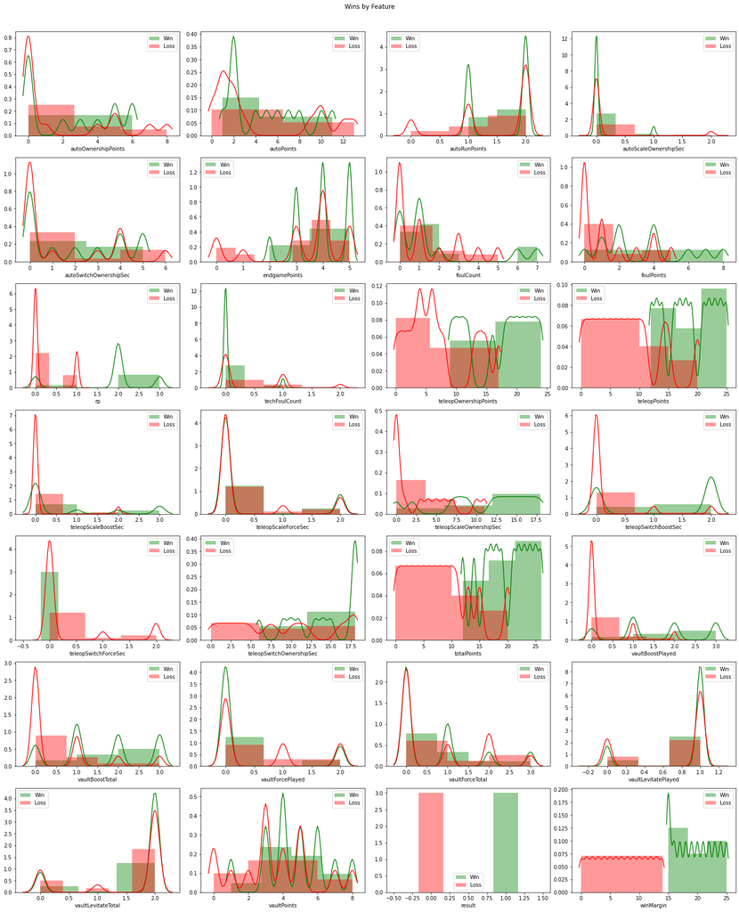

```python
fig = plt.figure(figsize = (20, 25))
j = 0
for i in data.columns:
    plt.subplot(7, 4, j+1 )
    j += 1
    sns.distplot(data[i][data['result']==1], color='g', label = 'Win', kde_kws={'bw': 0.1})
    sns.distplot(data[i][data['result']==0], color='r', label = 'Loss',kde_kws={'bw': 0.1})
    plt.legend(loc='best')
fig.suptitle('Wins by Feature')
fig.tight_layout()
fig.subplots_adjust(top=0.95 )
plt.show()
# data
```

## Metrics Analysis

# What is accuracy, recall, precision, Specificity and F1-score?

Accuracy, recall, precision, Specificity and F1-score are all obtained from Confision Matrix elements known as : TN, FP, FN, TP Accuracy: overall, how often is the classifier correct? -> $accuracy = \frac {TP + TN}{TP+TN+FP+FN}$

Classification error: overall, how often is the classifier incorrect? -> $error = 1- accuracy = \frac {FP + FN}{TP + TN + FP + FN}$

Recall: when the actual value is positive, how often is the prediction correct? -> $recall = \frac {TP}{TP + FN}$

Precision: When a positive value is predicted, how often is the prediction correct? -> $precision = \frac {TP}{TP + FP}$

Specificity: When the actual value is negative, how often is the prediction correct? -> $Specificity = \frac {TN}{TN + FP}$

F1-score = 2 x (Precision x Recall )/(Precision + Recall)

```python
svc=SVC() # The default kernel used by SVC is the gaussian kernel
svc.fit(x_train, y_train)
prediction = svc.predict(x_test)
prediction
```

```
array([0., 0., 1., 0., 0., 0., 0., 1., 0.])
```

```python
# Instantiate logistic regression model
logreg = LogisticRegression()

# fit model
# Train the model with X_train and y_train
logreg.fit(x_train, y_train)

# Pass X_test into predict method -> call the result as y_pred
y_pred = logreg.predict(x_test)
print(y_pred)
```

```
[0. 0. 1. 0. 0. 0. 0. 1. 0.]
```

```python
# SVC gaussian kernel
find_metrix(y_test, prediction)
# print("Accuracy:",metrics.accuracy_score(y_test, prediction))
```

```
[[7 0]
 [0 2]]
𝑎𝑐𝑐𝑢𝑟𝑎𝑐𝑦: 1.0
𝑒𝑟𝑟𝑜𝑟 =1−𝑎𝑐𝑐𝑢𝑟𝑎𝑐𝑦: 0.0
𝑟𝑒𝑐𝑎𝑙𝑙 1.0
𝑝𝑟𝑒𝑐𝑖𝑠𝑖𝑜𝑛 1.0
𝑆𝑝𝑒𝑐𝑖𝑓𝑖𝑐𝑖𝑡𝑦 1.0
f1 1.0
```

```python
# Logistic Regresstion
find_metrix(y_test, y_pred)
# print("Accuracy:",metrics.accuracy_score(y_test, y_pred))
```

```
[[7 0]
 [0 2]]
𝑎𝑐𝑐𝑢𝑟𝑎𝑐𝑦: 1.0
𝑒𝑟𝑟𝑜𝑟 =1−𝑎𝑐𝑐𝑢𝑟𝑎𝑐𝑦: 0.0
𝑟𝑒𝑐𝑎𝑙𝑙 1.0
𝑝𝑟𝑒𝑐𝑖𝑠𝑖𝑜𝑛 1.0
𝑆𝑝𝑒𝑐𝑖𝑓𝑖𝑐𝑖𝑡𝑦 1.0
f1 1.0
```

## PCA

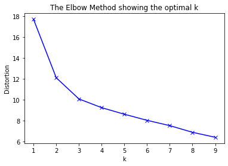

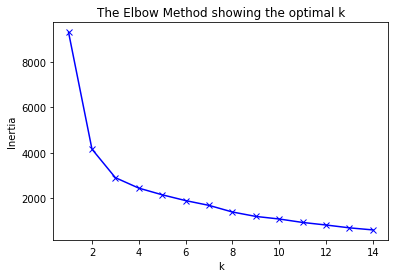

```python
distortions_Inertia(data)
```

[output not shown]

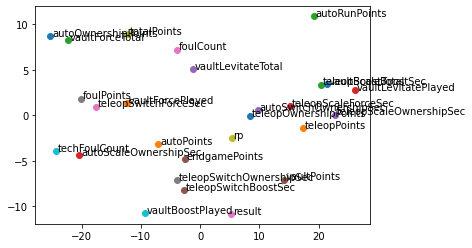

```python
pca = PCA(n_components=2)
X_r = pca.fit_transform(data)
# print(X_r)

for k, (i,j) in enumerate(zip(X_r[:, 0], X_r[:, 1])):
    try:
        print(data.columns[k], k, i, j)
        plt.scatter(i, j)
        plt.text(i+0.3, j, data.columns[k])
    except IndexError:
        pass

plt.show()
```

# Filter Method:

As the name suggest, in this method, you filter and take only the subset of the relevant features. The model is built after selecting the features. The filtering here is done using correlation matrix and it is most commonly done using Pearson correlation.

The correlation coefficient has values between -1 to 1

```
— A value closer to 0 implies weaker correlation (exact 0 implying no correlation)
— A value closer to 1 implies stronger positive correlation
— A value closer to -1 implies stronger negative correlation
```

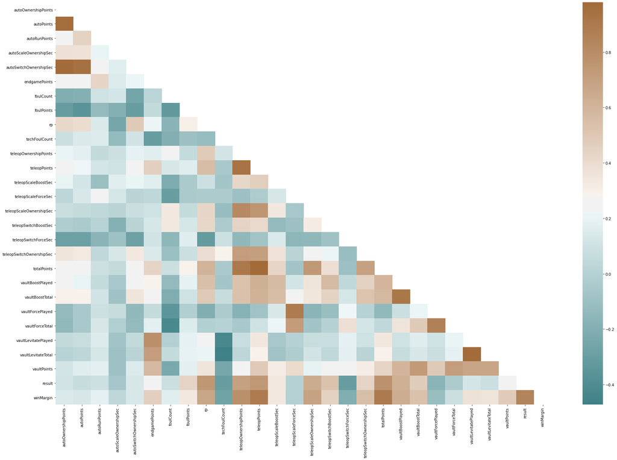

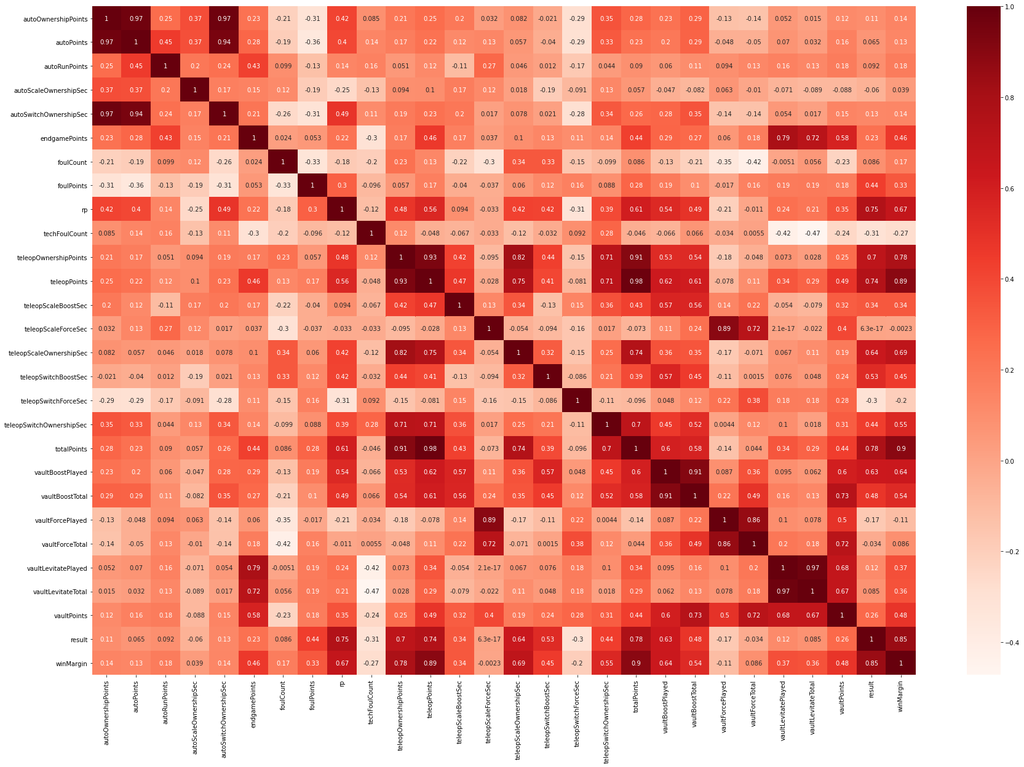

```python
#Using Pearson Correlation
plt.figure(figsize=(30,20))
corr = data.corr()

# Can be great to plot only a half matrix
mask = np.triu(np.ones_like(corr, dtype=np.bool))
cmap = sns.diverging_palette(200, 40, as_cmap=True)
sns.heatmap(corr, mask=mask, cmap=cmap)

plt.subplots(figsize=(30,20))
sns.heatmap(corr, annot=True, cmap=plt.cm.Reds)
plt.show()
```

```python
#Correlation with output variable
cor_target = abs(corr["result"])
#Selecting highly correlated features
relevant_features = cor_target[cor_target>0.7]
relevant_features
```

```
rp              0.751639
teleopPoints    0.742126
totalPoints     0.775128
result          1.000000
winMargin       0.847833
Name: result, dtype: float64
```

```python
simple_corr = data[['rp', 'teleopPoints', 'totalPoints', 'winMargin']].corr()
simple_corr
```

|  | rp | teleopPoints | totalPoints | winMargin |
| --- | --- | --- | --- | --- |
| rp | 1.000000 | 0.556193 | 0.606032 | 0.672015 |
| teleopPoints | 0.556193 | 1.000000 | 0.979398 | 0.892622 |
| totalPoints | 0.606032 | 0.979398 | 1.000000 | 0.896227 |
| winMargin | 0.672015 | 0.892622 | 0.896227 | 1.000000 |

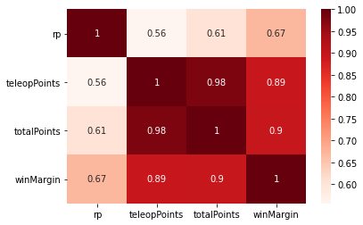

```python
sns.heatmap(simple_corr, annot=True, cmap=plt.cm.Reds)
```

### As we can see, the features [rp, teleopPoints, totalPoints, and winMargin] are highly correlated with the output variable result.

Hence we will drop all other features apart from these. However **this is not the end of the process**. One of the assumptions of **linear regression** is that the independent variables need to be uncorrelated with each other. If these variables are correlated with each other, then we need to keep only one of them and drop the rest. So let us check the correlation of selected features with each other. This can be done either by visually checking it from the above correlation matrix or from the code snippet below.

```python
compare_feature_correlation(data, corr)
```

```
Index(['autoOwnershipPoints', 'autoRunPoints', 'autoScaleOwnershipSec',
       'endgamePoints', 'foulCount', 'foulPoints', 'rp', 'techFoulCount',
       'teleopOwnershipPoints', 'teleopScaleBoostSec', 'teleopScaleForceSec',
       'teleopScaleOwnershipSec', 'teleopSwitchBoostSec',
       'teleopSwitchForceSec', 'teleopSwitchOwnershipSec', 'vaultBoostPlayed',
       'vaultForcePlayed', 'vaultForceTotal', 'vaultLevitatePlayed',
       'vaultPoints', 'result', 'winMargin'],
      dtype='object')
```

| Event | Match | Alliance | autoOwnershipPoints | autoRunPoints | autoScaleOwnershipSec | endgamePoints | foulCount | foulPoints | rp | techFoulCount | teleopOwnershipPoints | teleopScaleBoostSec | teleopScaleForceSec | teleopScaleOwnershipSec | teleopSwitchBoostSec | teleopSwitchForceSec | teleopSwitchOwnershipSec | vaultBoostPlayed | vaultForcePlayed | vaultForceTotal | vaultLevitatePlayed | vaultPoints | result | winMargin |
| --- | --- | --- | --- | --- | --- | --- | --- | --- | --- | --- | --- | --- | --- | --- | --- | --- | --- | --- | --- | --- | --- | --- | --- | --- |
| waahs | qf4m1 | red | 0.0 | 2.0 | 0.0 | 5.0 | 6.0 | 2.0 | 0.0 | 0.0 | 24.0 | 0.0 | 0.0 | 18.0 | 2.0 | 0.0 | 13.0 | 1.0 | 0.0 | 0.0 | 1.0 | 4.0 | 1.0 | 22.0 |
|  | qf4m2 | red | 2.0 | 2.0 | 1.0 | 3.0 | 1.0 | 2.0 | 0.0 | 0.0 | 16.0 | 3.0 | 2.0 | 7.0 | 0.0 | 0.0 | 18.0 | 2.0 | 2.0 | 2.0 | 0.0 | 4.0 | 1.0 | 15.0 |
|  | qm1 | red | 0.0 | 1.0 | 0.0 | 0.0 | 4.0 | 2.0 | 0.0 | 0.0 | 4.0 | 0.0 | 0.0 | 11.0 | 0.0 | 0.0 | 0.0 | 0.0 | 0.0 | 0.0 | 0.0 | 2.0 | 0.0 | 7.0 |
|  | qm15 | blue | 6.0 | 1.0 | 0.0 | 4.0 | 1.0 | 1.0 | 2.0 | 0.0 | 21.0 | 2.0 | 0.0 | 12.0 | 2.0 | 0.0 | 18.0 | 3.0 | 0.0 | 0.0 | 1.0 | 6.0 | 1.0 | 20.0 |
|  | qm19 | red | 0.0 | 1.0 | 0.0 | 4.0 | 2.0 | 3.0 | 0.0 | 0.0 | 7.0 | 0.0 | 0.0 | 0.0 | 0.0 | 0.0 | 11.0 | 0.0 | 0.0 | 0.0 | 1.0 | 3.0 | 0.0 | 12.0 |
|  | qm27 | red | 3.0 | 1.0 | 0.0 | 3.0 | 1.0 | 8.0 | 2.0 | 0.0 | 9.0 | 0.0 | 0.0 | 2.0 | 0.0 | 0.0 | 18.0 | 0.0 | 0.0 | 0.0 | 1.0 | 3.0 | 1.0 | 15.0 |
|  | qm35 | blue | 0.0 | 2.0 | 0.0 | 4.0 | 0.0 | 7.0 | 2.0 | 0.0 | 10.0 | 0.0 | 2.0 | 9.0 | 2.0 | 0.0 | 6.0 | 3.0 | 2.0 | 3.0 | 1.0 | 8.0 | 1.0 | 19.0 |
|  | qm39 | blue | 5.0 | 1.0 | 0.0 | 5.0 | 0.0 | 2.0 | 2.0 | 0.0 | 19.0 | 3.0 | 0.0 | 15.0 | 0.0 | 0.0 | 11.0 | 2.0 | 0.0 | 0.0 | 1.0 | 5.0 | 1.0 | 21.0 |
|  | qm45 | blue | 0.0 | 1.0 | 0.0 | 3.0 | 0.0 | 1.0 | 0.0 | 0.0 | 8.0 | 0.0 | 1.0 | 1.0 | 0.0 | 0.0 | 16.0 | 0.0 | 2.0 | 2.0 | 1.0 | 5.0 | 0.0 | 11.0 |
|  | qm53 | blue | 5.0 | 2.0 | 0.0 | 5.0 | 1.0 | 1.0 | 3.0 | 0.0 | 20.0 | 1.0 | 0.0 | 13.0 | 0.0 | 0.0 | 18.0 | 2.0 | 0.0 | 1.0 | 1.0 | 6.0 | 1.0 | 24.0 |
|  | qm55 | red | 0.0 | 2.0 | 0.0 | 5.0 | 0.0 | 5.0 | 0.0 | 1.0 | 6.0 | 0.0 | 0.0 | 0.0 | 0.0 | 0.0 | 10.0 | 0.0 | 0.0 | 0.0 | 1.0 | 3.0 | 0.0 | 10.0 |
|  | qm64 | blue | 5.0 | 2.0 | 0.0 | 5.0 | 0.0 | 0.0 | 1.0 | 0.0 | 0.0 | 0.0 | 2.0 | 4.0 | 0.0 | 0.0 | 1.0 | 0.0 | 2.0 | 2.0 | 1.0 | 5.0 | 0.0 | 8.0 |
|  | qm68 | red | 0.0 | 2.0 | 0.0 | 4.0 | 5.0 | 0.0 | 0.0 | 0.0 | 2.0 | 0.0 | 0.0 | 0.0 | 0.0 | 0.0 | 3.0 | 0.0 | 0.0 | 0.0 | 1.0 | 3.0 | 0.0 | 6.0 |
|  | qm9 | red | 0.0 | 0.0 | 0.0 | 4.0 | 3.0 | 1.0 | 0.0 | 0.0 | 6.0 | 0.0 | 0.0 | 0.0 | 2.0 | 1.0 | 8.0 | 1.0 | 1.0 | 1.0 | 1.0 | 5.0 | 0.0 | 3.0 |
|  | sf2m1 | blue | 1.0 | 2.0 | 0.0 | 3.0 | 1.0 | 0.0 | 0.0 | 1.0 | 4.0 | 0.0 | 0.0 | 0.0 | 0.0 | 0.0 | 5.0 | 0.0 | 0.0 | 0.0 | 0.0 | 0.0 | 0.0 | 1.0 |
| waamv | qm10 | red | 4.0 | 2.0 | 0.0 | 3.0 | 0.0 | 0.0 | 1.0 | 1.0 | 15.0 | 0.0 | 2.0 | 6.0 | 0.0 | 0.0 | 18.0 | 0.0 | 2.0 | 2.0 | 1.0 | 7.0 | 0.0 | 9.0 |
|  | qm13 | red | 4.0 | 1.0 | 0.0 | 2.0 | 2.0 | 4.0 | 2.0 | 1.0 | 22.0 | 0.0 | 0.0 | 14.0 | 2.0 | 0.0 | 15.0 | 1.0 | 0.0 | 0.0 | 0.0 | 1.0 | 1.0 | 18.0 |
|  | qm19 | blue | 8.0 | 2.0 | 2.0 | 5.0 | 3.0 | 0.0 | 0.0 | 0.0 | 13.0 | 0.0 | 0.0 | 7.0 | 0.0 | 0.0 | 12.0 | 0.0 | 0.0 | 0.0 | 1.0 | 3.0 | 0.0 | 13.0 |
|  | qm30 | red | 0.0 | 1.0 | 0.0 | 3.0 | 0.0 | 6.0 | 2.0 | 0.0 | 18.0 | 0.0 | 0.0 | 16.0 | 0.0 | 0.0 | 10.0 | 0.0 | 0.0 | 0.0 | 1.0 | 3.0 | 1.0 | 17.0 |
|  | qm34 | blue | 6.0 | 2.0 | 0.0 | 5.0 | 0.0 | 4.0 | 3.0 | 0.0 | 11.0 | 0.0 | 0.0 | 0.0 | 2.0 | 0.0 | 18.0 | 3.0 | 0.0 | 1.0 | 1.0 | 7.0 | 1.0 | 23.0 |
|  | qm36 | red | 0.0 | 2.0 | 0.0 | 4.0 | 0.0 | 4.0 | 0.0 | 0.0 | 1.0 | 0.0 | 0.0 | 0.0 | 0.0 | 2.0 | 2.0 | 0.0 | 1.0 | 1.0 | 1.0 | 4.0 | 0.0 | 5.0 |
|  | qm45 | blue | 0.0 | 1.0 | 0.0 | 4.0 | 0.0 | 4.0 | 0.0 | 1.0 | 17.0 | 2.0 | 0.0 | 10.0 | 0.0 | 2.0 | 17.0 | 2.0 | 1.0 | 3.0 | 1.0 | 8.0 | 0.0 | 14.0 |
|  | qm49 | red | 0.0 | 2.0 | 0.0 | 4.0 | 7.0 | 0.0 | 2.0 | 0.0 | 23.0 | 0.0 | 0.0 | 17.0 | 2.0 | 0.0 | 14.0 | 1.0 | 0.0 | 0.0 | 1.0 | 4.0 | 1.0 | 25.0 |
|  | qm5 | blue | 0.0 | 0.0 | 0.0 | 0.0 | 0.0 | 1.0 | 0.0 | 0.0 | 3.0 | 0.0 | 0.0 | 0.0 | 0.0 | 0.0 | 4.0 | 0.0 | 0.0 | 0.0 | 0.0 | 0.0 | 0.0 | 0.0 |
|  | qm54 | blue | 0.0 | 2.0 | 0.0 | 4.0 | 1.0 | 4.0 | 2.0 | 0.0 | 12.0 | 0.0 | 0.0 | 8.0 | 2.0 | 0.0 | 9.0 | 1.0 | 0.0 | 1.0 | 1.0 | 5.0 | 1.0 | 16.0 |
|  | qm63 | blue | 7.0 | 2.0 | 0.0 | 4.0 | 1.0 | 0.0 | 1.0 | 0.0 | 5.0 | 0.0 | 0.0 | 5.0 | 0.0 | 0.0 | 7.0 | 0.0 | 0.0 | 0.0 | 1.0 | 4.0 | 0.0 | 2.0 |
|  | qm65 | red | 5.0 | 2.0 | 0.0 | 1.0 | 1.0 | 0.0 | 1.0 | 2.0 | 14.0 | 0.0 | 0.0 | 3.0 | 1.0 | 0.0 | 18.0 | 1.0 | 0.0 | 0.0 | 0.0 | 1.0 | 0.0 | 4.0 |

### Now, the dataset has only those columns with correlation less than 0.9

# Embedded Method

Embedded methods are iterative in a sense that takes care of each iteration of the model training process and carefully extract those features which contribute the most to the training for a particular iteration. Regularization methods are the most commonly used embedded methods which penalize a feature given a coefficient threshold.

Here we will do feature selection using Lasso regularization. If the feature is irrelevant, lasso penalizes it’s coefficient and make it 0. Hence the features with coefficient = 0 are removed and the rest are taken.

```python
reg = LassoCV()
reg.fit(data, result)
print("Best alpha using built-in LassoCV: %f" %reg.alpha_)
print("Best score using built-in LassoCV: %f" %reg.score(data, result))
coef = pd.Series(reg.coef_, index = data.columns)
# coef

ct, cf = 0, 0
for i in coef:
    if i != 0:
        ct += 1
    if i == 0:
        cf += 1
print("Lasso picked " + str(ct) + " variables and eliminated the other " +  str(cf) + " variables")
```

```
Best alpha using built-in LassoCV: 0.003107
Best score using built-in LassoCV: 0.999415
Lasso picked 10 variables and eliminated the other 18 variables
```

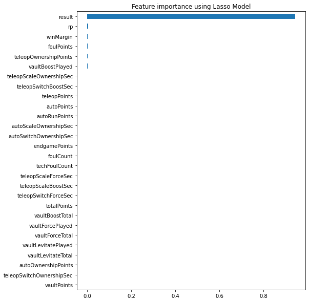

```python
imp_coef = coef.sort_values()
import matplotlib
matplotlib.rcParams['figure.figsize'] = (8.0, 10.0)
imp_coef.plot(kind = "barh")
plt.title("Feature importance using Lasso Model")
```

# Finding Important Features in Scikit-learn

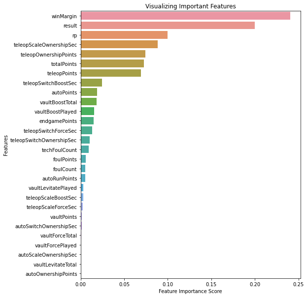

```python
#Create a Gaussian Classifier
clf=RandomForestClassifier(n_estimators=100)

#Train the model using the training sets y_pred=clf.predict(X_test)
clf.fit(x_train,y_train)

feature_imp = pd.Series(clf.feature_importances_,index=data.columns).sort_values(ascending=False)
feature_imp

# Creating a bar plot
sns.barplot(x=feature_imp, y=feature_imp.index)
# Add labels to your graph
plt.xlabel('Feature Importance Score')
plt.ylabel('Features')
plt.title("Visualizing Important Features")
# plt.legend()
plt.show()
```

[figure not shown]

# Conclusions:

## Result

#### The features rp, teleopPoints, totalPoints, and winMargin are highly correlated with the result of winning or not.

[output not shown]

# Future Steps

- Experiment with different C values for SVC
- Other models and methods (Solo Decision Tree, Gradient Boosting, etc.)
- Utilize the list of other teams and events
- Are there particular alliances that, when taken, can predict a win?
- Can a model predict the next winner of a game?